# Skúška

Veronika Benková

28 12 2021

Na analýzu dát som si vybrala excelový súbor titanic, ktorý je voľne dostupný na internete

```r
library(tidyverse)
```

```r
library(ggplot2)
library(readr)
library(utils)
```

```r
titanic <- read.csv("https://raw.githubusercontent.com/VBenkova/R-ko/main/titanic.csv")
View(titanic)
```

Z tabuľky som si na anlýzu vybrala 4 skupiny dát: Survived, PClass, Sex a Age a tabuľku som si vizualizovala. V skupinách dát PClass, Sex a Age porovnám jednotlivé počty preživších (P- prežili) a mŕtvych (N- neprežili),

```r
titanic2 <- titanic %>%
  select(-PassengerId, -Name, -SibSp, -Parch, -Ticket, -Cabin, -Fare, -Embarked) %>%
  mutate(Survived = factor(Survived, levels = c(0, 1), labels = c("N", "P")),
         Sex = factor(Sex, levels=c("male", "female"), labels=c("m", "ž")),
         Pclass = factor(Pclass, levels=c(1,2,3), labels=c("Prvá", "Druhá", "Tretia")))
colnames(titanic2) <- c("Prežili/neprežili", "Trieda", "Pohlavie", "Vek")
View(titanic2)
```

V prvom grafe som si zobrazila, aký bol celkový počet mŕtvych ku živým bez ohľadu na vek, triedu a pohlavie. Vidíme, že celkovo zomrelo 549 ľudí a prežilo 342.

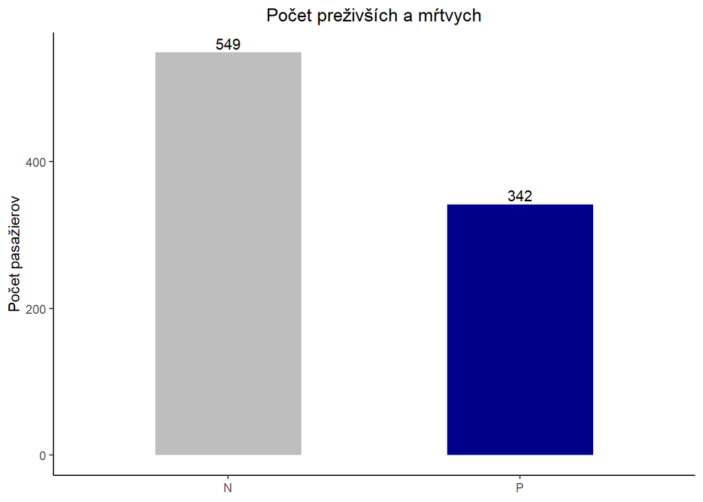

```r
titanic %>%
  ggplot(aes(x= `Prežili/neprežili`)) +
  geom_bar(width= 0.5, fill=c("grey", "darkblue")) +
  geom_text(stat = "count", aes(label=..count..), vjust= -0.3)+
 theme_classic()  +
  theme(
    plot.title= element_text(hjust=0.5),
 )+
   labs(title = "Počet preživších a mŕtvych", x = NULL, y = "Počet pasažierov")
```

V nasledujúcom grafe som si vizualizovala, aké sú množstvá preživších a mŕtvych vzľadom na pohlavie. Z tohto grafu možno vyčítať, že na lodi sa nachádzalo viac mužov ako žien, no potopenie Titanicu prežilo viac žien.

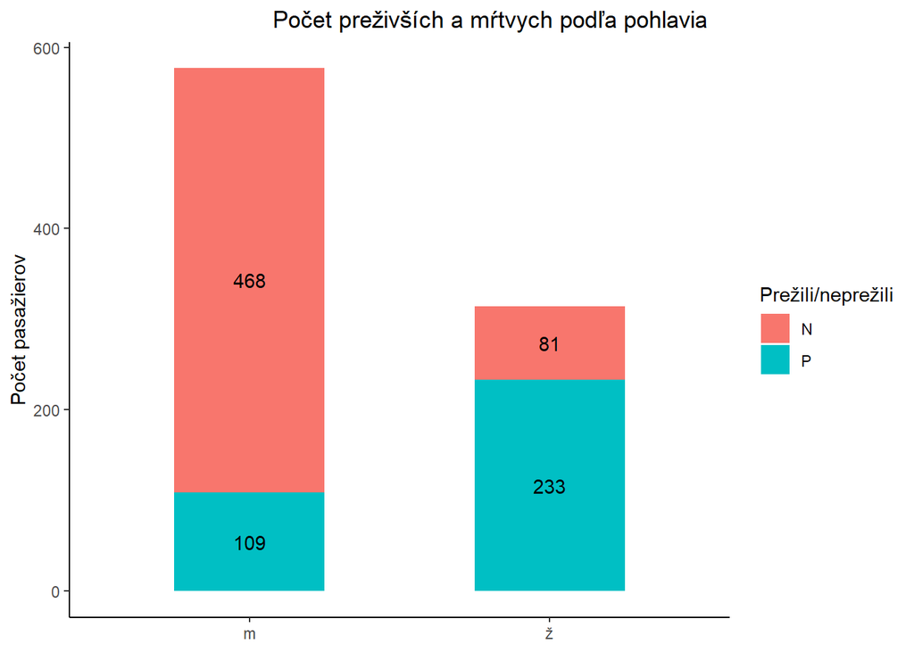

```r
titanic2 %>%
  ggplot(aes(x = Pohlavie, fill = `Prežili/neprežili`)) +
  geom_bar(width = 0.5) +
  geom_text (stat="count", aes(label=..count..), position= position_stack(vjust=0.5))+
  theme_classic() +
  theme(
    plot.title = element_text( hjust = 0.9),

  ) +
  labs(title = "Počet preživších a mŕtvych podľa pohlavia", x = NULL, y = "Počet pasažierov")
```

Na grafe nižiše možno vidieť, že najviac ľudí cestovalo 3. triedou a najmenej 2. Vidíme, že z 1. triedy prežila viac než polovica, z druhej triedy bol rozdiel medzi preživšími a mŕtvymi 10 ľudí, pričom viac ľudí zahynulo a veľká časť cestujúcich 3. triedy zahynula.

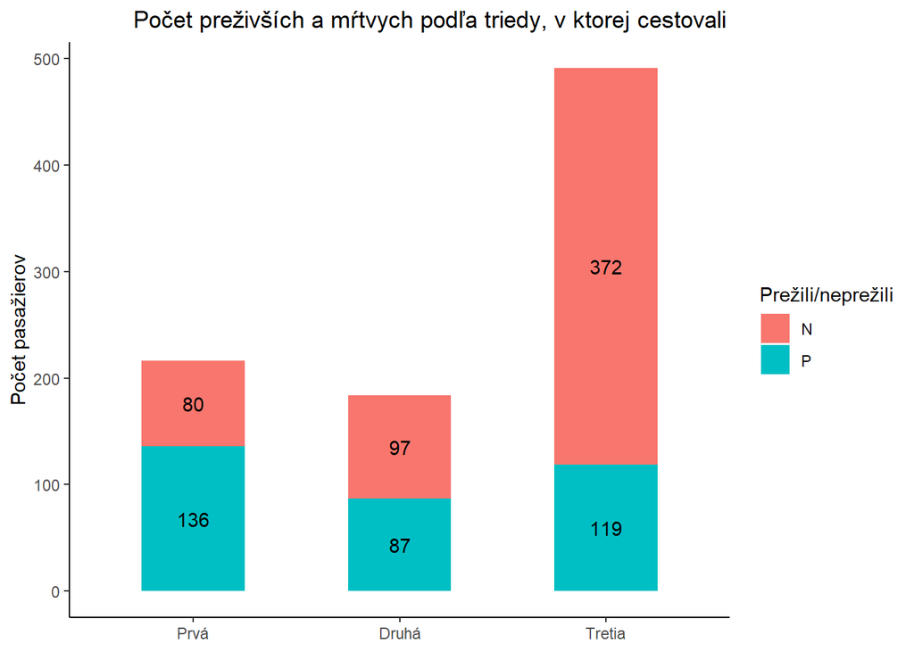

```r
titanic2 %>%
  ggplot(aes(x = Trieda, fill = `Prežili/neprežili`)) +
  geom_bar(width = 0.5) +
  geom_text (stat="count", aes(label=..count..), position= position_stack(vjust=0.5))+
  theme_classic() +
  theme(
    plot.title = element_text(hjust = 0.95),
  ) +
  labs(title = "Počet preživších a mŕtvych podľa triedy, v ktorej cestovali", x = NULL, y = "Počet pasažierov")
```

V naslesledujúch boxplotoch vidíme porovnanie veku preživších a mŕtvych nezávisle od triedy, veku a pohlavia. Niektoré dáta však neobsahujú vek onoho konkrétneho pasažiara, preto tieto hodnoty nie sú zahrnuté v grafe, a teda priemerná hodnota veku nemusí byť úplne presná.

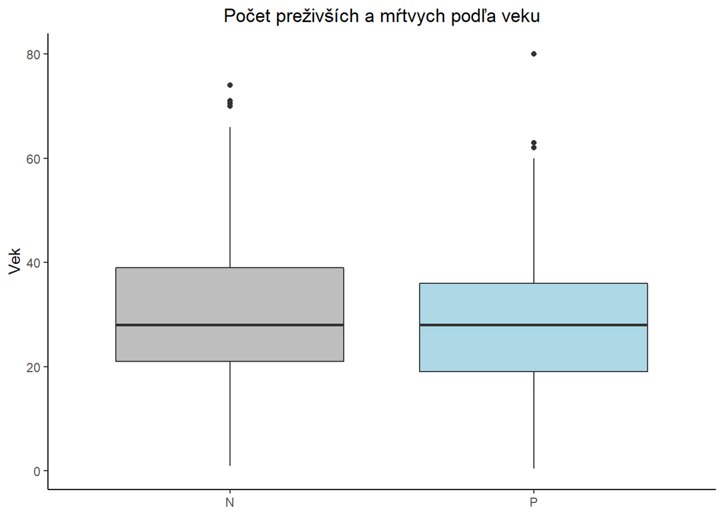

```r
titanic2 %>%
  ggplot(aes(x = `Prežili/neprežili`, y = Vek)) +
  geom_boxplot(fill=c("grey", "lightblue")) +
  theme_classic() +
  theme(
    plot.title = element_text(hjust = 0.5),
  ) +
  labs(title = "Počet preživších a mŕtvych podľa veku", x = NULL)
```

```r
tab1<- aggregate(Vek~`Prežili/neprežili`, data=titanic2, FUN = mean)
View(tab1)
```

```r
t.test(Vek~`Prežili/neprežili`, var.equal=TRUE, data=titanic2)
```

```
##
##  Two Sample t-test
##
## data:  Vek by Prežili/neprežili
## t = 2.0667, df = 712, p-value = 0.03912
## alternative hypothesis: true difference in means between group N and group P is not equal to 0
## 95 percent confidence interval:
##  0.114181 4.450798
## sample estimates:
## mean in group N mean in group P
##        30.62618        28.34369
```